Walter Valera

# Exploring Cryptocurrency Market Trends Using CoinLore and CoinGecko API Data

In this project, we will be utilizing the CoinLore and CoinGecko APIs to retrieve data for real-time and historical cryptocurrency data, exploring market trends of various cryptocurrencies.

## Introduction

Cryptocurrencies have revolutionized the world of finance, offering decentralized and secure digital transactions. This project aims to explore market trends in the cryptocurrency world using data from the CoinLore and CoinGecko APIs. CoinLore offers a public and free cryptocurrency API for developers and researchers, providing independent data for over 12,000 crypto coins and more than 300 crypto exchanges. CoinGecko is another public API that offers historical data for over 15,000 coins and 1,000 exchanges. Our aim is to utilize these APIs to understand how different cryptocurrencies perform, particularly Bitcoin (`BTC`) and Ethereum (`ETH`), and identify key factors by observing their real-time price, historical trends, and current market data. When collecting and analyzing data, it is important to consider the ethical implications. The use of public APIs, such as CoinLore and CoinGecko, ensures that the data we use is freely available to the public and that this data is solely intended for research purposes. By using public APIs, we also ensure that we are respecting user privacy and data security, and that we are also not exposing sensitive information. To sum up, this project aims to utilize the CoinLore and CoinGecko API to analyze market trends and performance indicators to obtain a deeper understanding of the key factors that drive the cryptocurrency market.

## Data Exploration

```python
import requests
import pandas as pd

# Fetch global data from the CoinLore API
r = requests.get("https://api.coinlore.net/api/global/")
global_data = r.json()

# Convert JSON data to DataFrame
df = pd.DataFrame.from_dict(global_data[0], orient='index')

# Display global data
df
```

|  | 0 |
| --- | --- |
| coins_count | 13413 |
| active_markets | 34288 |
| total_mcap | 3597053977184.033203 |
| total_volume | 286218910446.241821 |
| btc_d | 54.67 |
| eth_d | 12.99 |
| mcap_change | -0.48 |
| volume_change | -0.51 |
| avg_change_percent | 0.07 |
| volume_ath | 344187126292428700 |
| mcap_ath | 33233454769163.914062 |

```python
# Fetch ticker data from the CoinLore API
r2 = requests.get("https://api.coinlore.net/api/tickers/")
tickers_data = r2.json()

# Convert JSON data to DataFrame
tickers = tickers_data['data']
tickers_df = pd.DataFrame(tickers)

# Convert 'market_cap_usd' to numeric values
tickers_df['market_cap_usd'] = pd.to_numeric(tickers_df['market_cap_usd'], errors='coerce')

# Subset data for top 20 cryptocurrencies by market cap
top_20 = tickers_df.nlargest(20, 'market_cap_usd')

# Display top 20 cryptocurrencies
top_20[['id', 'symbol', 'name', 'nameid', 'rank', 'price_usd', 'market_cap_usd', 'volume24']]
```

|  | id | symbol | name | nameid | rank | price_usd | market_cap_usd | volume24 |
| --- | --- | --- | --- | --- | --- | --- | --- | --- |
| 0 | 90 | BTC | Bitcoin | bitcoin | 1 | 99423.53 | 1.967903e+12 | 5.483457e+10 |
| 1 | 80 | ETH | Ethereum | ethereum | 2 | 3887.44 | 4.673805e+11 | 3.078950e+10 |
| 2 | 2710 | BNB | Binance Coin | binance-coin | 3 | 705.48 | 1.176753e+11 | 1.192638e+09 |
| 3 | 518 | USDT | Tether | tether | 4 | 1.00 | 1.144584e+11 | 1.210473e+11 |
| 4 | 48543 | SOL | Solana | solana | 5 | 226.55 | 1.052781e+11 | 3.743882e+09 |
| 5 | 58 | XRP | XRP | ripple | 6 | 2.34 | 1.005949e+11 | 7.617793e+09 |
| 6 | 2 | DOGE | Dogecoin | dogecoin | 7 | 0.404959 | 5.957634e+10 | 4.543846e+09 |
| 7 | 257 | ADA | Cardano | cardano | 8 | 1.11 | 3.983797e+10 | 1.779185e+09 |
| 8 | 46971 | STETH | Staked Ether | staked-ether | 9 | 3877.88 | 3.575483e+10 | 2.256012e+08 |
| 9 | 33285 | USDC | USD Coin | usd-coin | 10 | 0.999741 | 3.412744e+10 | 7.212301e+09 |
| 10 | 2713 | TRX | TRON | tron | 11 | 0.294711 | 2.565679e+10 | 2.417819e+09 |
| 11 | 44883 | AVAX | Avalanche | avalanche | 12 | 52.30 | 2.065091e+10 | 1.085367e+09 |
| 12 | 2751 | LINK | ChainLink | chainlink | 13 | 29.01 | 1.764081e+10 | 2.834871e+09 |
| 13 | 45088 | SHIB | Shiba Inu | shiba-inu | 14 | 0.000028 | 1.649731e+10 | 8.010651e+07 |
| 14 | 54683 | TON | TON Coin | toncoin | 15 | 6.33 | 1.592767e+10 | 1.338533e+08 |
| 15 | 33422 | WBTC | Wrapped Bitcoin | wrapped-bitcoin | 16 | 99184.05 | 1.535191e+10 | 9.109468e+07 |
| 16 | 32610 | WETH | WETH | weth | 17 | 3884.04 | 1.310987e+10 | 8.317250e+07 |
| 17 | 89 | XLM | Stellar | stellar | 18 | 0.422253 | 1.273343e+10 | 6.413345e+08 |
| 18 | 45219 | DOT | Polkadot | polkadot | 19 | 9.00 | 1.254476e+10 | 9.091599e+08 |
| 19 | 93845 | SUI | Sui | sui | 20 | 4.66 | 1.171156e+10 | 1.649949e+09 |

This DataFrame showcases the top 20 Cryptocurrencies by market cap in USD (total value of the coins that have been mined). Each row gives the name of the cryptocurrency, their symbol, their nameid, rank, price, market cap, and trading volume of coin for last 24h in USD (the quantity of that coin that has been exchanged between buyers and sellers within the last 24 hours).

```python
# Convert 'price_usd' to numeric values
tickers_df['price_usd'] = pd.to_numeric(tickers_df['price_usd'], errors='coerce')

# Subset data for top 20 crpytocurrencies by price
most_expensive = tickers_df.nlargest(20, 'price_usd')

# Display top 20 most expensive cryptocurrencies
most_expensive[['id', 'symbol', 'name', 'nameid', 'rank', 'price_usd', 'market_cap_usd', 'volume24']]
```

|  | id | symbol | name | nameid | rank | price_usd | market_cap_usd | volume24 |
| --- | --- | --- | --- | --- | --- | --- | --- | --- |
| 0 | 90 | BTC | Bitcoin | bitcoin | 1 | 99423.53 | 1.967903e+12 | 5.483457e+10 |
| 15 | 33422 | WBTC | Wrapped Bitcoin | wrapped-bitcoin | 16 | 99184.05 | 1.535191e+10 | 9.109468e+07 |
| 38 | 96901 | WBETH | Wrapped Beacon ETH | wrapped-beacon-eth | 39 | 4104.87 | 3.746950e+09 | 1.125733e+07 |
| 1 | 80 | ETH | Ethereum | ethereum | 2 | 3887.44 | 4.673805e+11 | 3.078950e+10 |
| 16 | 32610 | WETH | WETH | weth | 17 | 3884.04 | 1.310987e+10 | 8.317250e+07 |
| 8 | 46971 | STETH | Staked Ether | staked-ether | 9 | 3877.88 | 3.575483e+10 | 2.256012e+08 |
| 64 | 12377 | MKR | Maker | maker | 65 | 2030.07 | 1.888783e+09 | 2.046546e+08 |
| 2 | 2710 | BNB | Binance Coin | binance-coin | 3 | 705.48 | 1.176753e+11 | 1.192638e+09 |
| 33 | 121619 | TAO | Bittensor | bittensor | 34 | 576.54 | 4.116830e+09 | 2.172263e+08 |
| 20 | 2321 | BCH | Bitcoin Cash | bitcoin-cash | 21 | 535.12 | 1.059500e+10 | 4.209325e+08 |
| 28 | 46018 | AAVE | Aave | aave | 29 | 367.72 | 5.471150e+09 | 1.573058e+09 |
| 4 | 48543 | SOL | Solana | solana | 5 | 226.55 | 1.052781e+11 | 3.743882e+09 |
| 37 | 28 | XMR | Monero | monero | 38 | 203.95 | 3.762193e+09 | 1.407452e+08 |
| 71 | 33085 | QNT | Quant | quant | 72 | 139.47 | 1.683751e+09 | 9.580284e+07 |
| 24 | 1 | LTC | Litecoin | litecoin | 25 | 118.91 | 8.894708e+09 | 1.307125e+09 |
| 87 | 33234 | BCHSV | Bitcoin SV | bitcoin-cash-sv | 88 | 66.26 | 1.276587e+09 | 1.549106e+08 |
| 46 | 33531 | OKB | OKB | okb | 47 | 54.92 | 3.294960e+09 | 4.540987e+07 |
| 11 | 44883 | AVAX | Avalanche | avalanche | 12 | 52.30 | 2.065091e+10 | 1.085367e+09 |
| 23 | 2753 | CNX | Cryptonex | cryptonex | 24 | 50.85 | 9.002531e+09 | 1.261420e+07 |
| 82 | 56821 | ENS | Ethereum Name Service | ethereum-name-service | 83 | 41.81 | 1.373024e+09 | 6.212029e+08 |

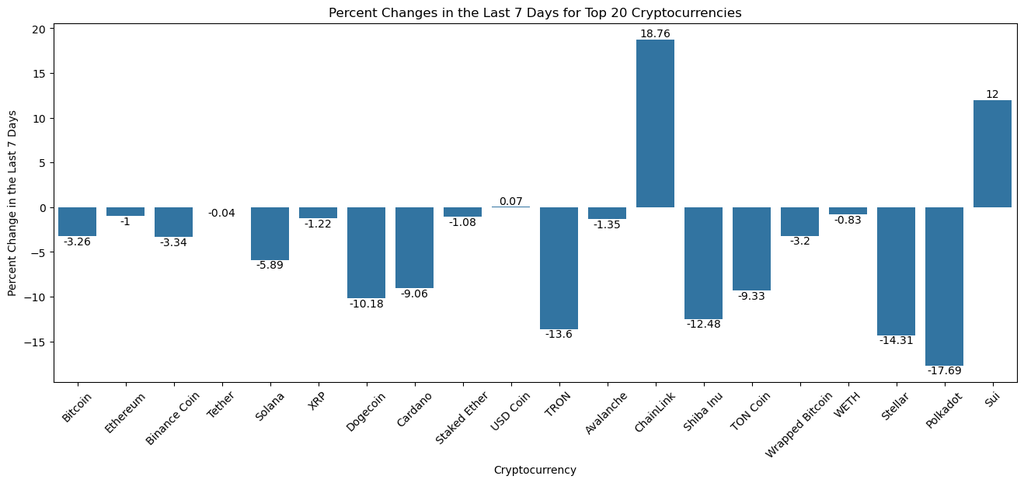

```python
import seaborn as sns
import matplotlib.pyplot as plt

# Convert 'percent_change_7d' to numeric values
tickers_df['percent_change_7d'] = pd.to_numeric(tickers_df['percent_change_7d'], errors='coerce')

# Top 20 cryptocurrencies (by market cap)
top_20_df = tickers_df.nlargest(20, 'market_cap_usd')

# Create the bar graph
plt.figure(figsize=(16, 6))
ax = sns.barplot(x='name', y='percent_change_7d', data=top_20_df)
ax.bar_label(ax.containers[0], fontsize=10)
plt.title('Percent Changes in the Last 7 Days for Top 20 Cryptocurrencies')
plt.xlabel('Cryptocurrency')
plt.ylabel('Percent Change in the Last 7 Days')
plt.xticks(rotation=45)
plt.show()
```

This graph showcases the price changes (percentage-wise) in the last 7 days for the Top 20 Cryptocurrencies (based on their market cap). We can observe from the graph that there have been significant price increases in ChainLink and Sui. We can also observe that there have been significant price drops in Polkadot, Stellar, TRON, and Shiba Inu. Coins like Tether, USD Coin, and Ethereum have remained stable in the past 7 days.

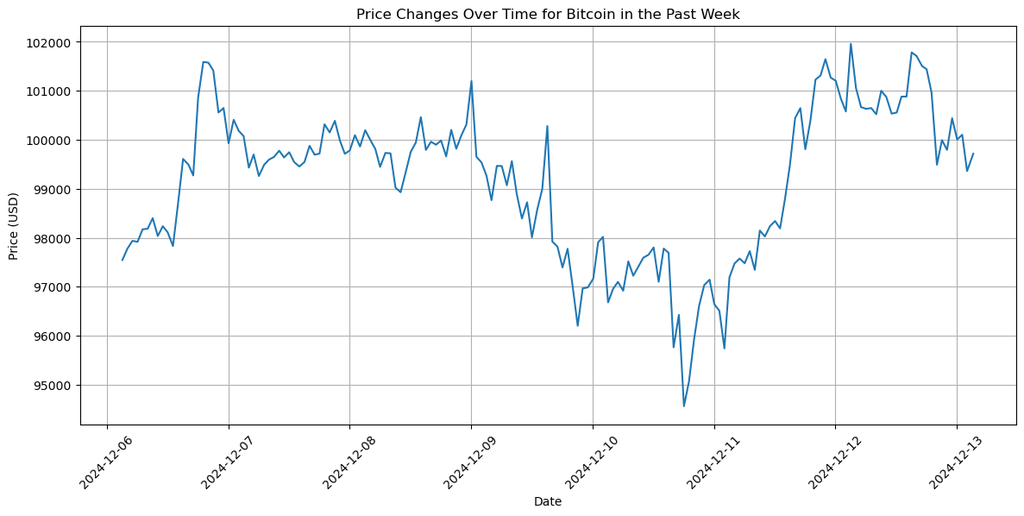

```python
# Fetch historical data from CoinGecko API
coin_id = 'bitcoin'
api_url = f"https://api.coingecko.com/api/v3/coins/{coin_id}/market_chart?vs_currency=usd&days=7"
response = requests.get(api_url)
data = response.json()

# Convert JSON data to DataFrame
prices = data['prices']
bitcoin_df = pd.DataFrame(prices, columns=['timestamp', 'price_usd'])

# Convert timestamp to datetime
bitcoin_df['timestamp'] = pd.to_datetime(bitcoin_df['timestamp'], unit='ms')

# Create line plot
plt.figure(figsize=(14, 6))
plt.plot(bitcoin_df['timestamp'], bitcoin_df['price_usd'])
plt.title("Price Changes Over Time for Bitcoin in the Past Week")
plt.xlabel('Date')
plt.ylabel('Price (USD)')
plt.xticks(rotation=45)
plt.grid(True)
plt.show()
```

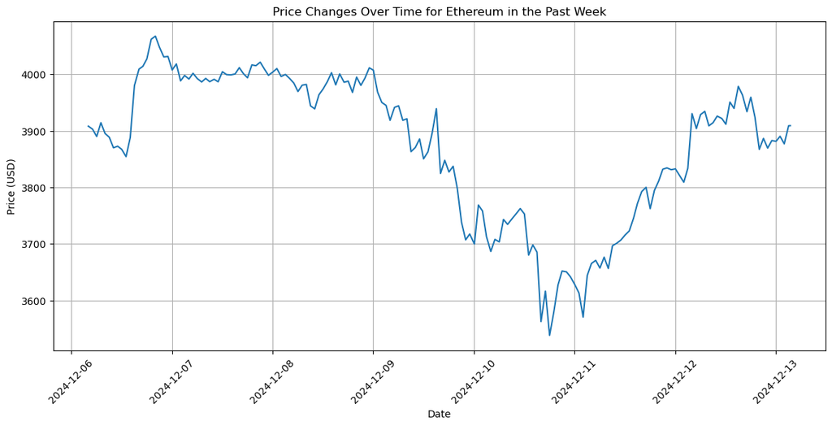

```python
# Fetch historical data from the CoinGecko API
coin_id = 'ethereum'
api_url = f"https://api.coingecko.com/api/v3/coins/{coin_id}/market_chart?vs_currency=usd&days=7"
response = requests.get(api_url)
data = response.json()

# Convert JSON data to DataFrame
prices = data['prices']
ethereum_df = pd.DataFrame(prices, columns=['timestamp', 'price_usd'])

# Convert timestamp to datetime
ethereum_df['timestamp'] = pd.to_datetime(ethereum_df['timestamp'], unit='ms')

# Create line plot
plt.figure(figsize=(14, 6))
plt.plot(ethereum_df['timestamp'], ethereum_df['price_usd'])
plt.title('Price Changes Over Time for Ethereum in the Past Week')
plt.xlabel('Date')
plt.ylabel('Price (USD)')
plt.xticks(rotation=45)
plt.grid(True)
plt.show()
```

This graph displays the price changes over time for Ethereum in the past week. Ethereum appears to also showcase a high volatility, experiencing price drops and raises in the past week. This week, Ethereum peaked at about 4100 USD on December 6, 2024, and from there kept decreasing all the way to about 3500 USD on December 10, 2024. However, the graph indicates that Ethereum appears to be rising in price as of recently.

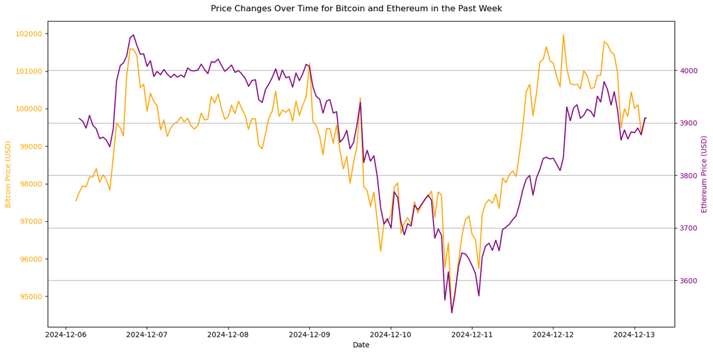

```python
# Create a dual-axis line plot to compare BTC and ETH prices in past week
fig, ax1 = plt.subplots(figsize=(14, 7))

# Lineplot for BTC history
ax1.plot(bitcoin_df['timestamp'], bitcoin_df['price_usd'], color='orange', label='Bitcoin')
ax1.set_xlabel('Date')
ax1.set_ylabel('Bitcoin Price (USD)', color='orange')
ax1.tick_params(axis='y', labelcolor='orange')

# Lineplot for ETH price history
ax2 = ax1.twinx()
ax2.plot(ethereum_df['timestamp'], ethereum_df['price_usd'], color='purple', label='Ethereum')
ax2.set_ylabel('Ethereum Price (USD)', color='purple')
ax2.tick_params(axis='y', labelcolor='purple')

fig.suptitle('Price Changes Over Time for Bitcoin and Ethereum in the Past Week')
fig.tight_layout()
plt.grid(True)
plt.show()
```

This graph compares the price changes of Bitcoin and Ethereum in the past week. Both BTC and ETH tend to experience the same amount of price volatility. The prices of BTC and ETH tend to follow the same trend of decreasing towards the middle of the week and spiking back up towards the weekend. We can likely find a potentially reasoning for this by looking at their trading volume in the past 24 hours (i.e. the quantity of these coins that have been exchanged in the past day).

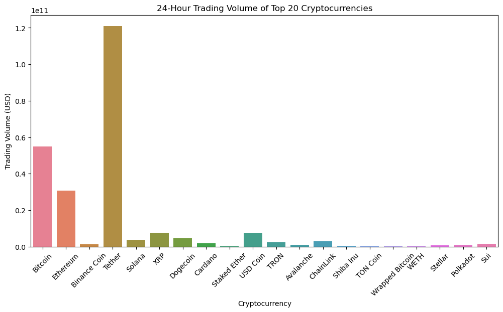

```python
# Convert 'volume24' to numeric values
tickers_df['volume24'] = pd.to_numeric(tickers_df['volume24'], errors='coerce')

# Top 20 cryptocurrencies (by market cap)
top_20_df = tickers_df.nlargest(20, 'market_cap_usd')

# Create a bar plot to show trading volume
plt.figure(figsize=(12, 6))
sns.barplot(x='name', y='volume24', data=top_20_df, hue='name')
plt.title('24-Hour Trading Volume of Top 20 Cryptocurrencies')
plt.xlabel('Cryptocurrency')
plt.ylabel('Trading Volume (USD)')
plt.xticks(rotation=45)
plt.show()
```

This graph showcases the 24-hour trading volume of the top 20 cryptocurrencies (by market cap). The trading volume of a cryptocurrency (`volume24`) is the amount of that cryptocurrency that has been bought and sold between traders in the past 24 hours. Higher trading volumes tend to mean that these cryptocurrencies are the most popular among traders, likely due to their price, volatility, liquidity, and market recognition. Cryptocurrencies with high volatility (such as `BTC` and `ETH`) appeal to many traders who are looking to make a quick profit from the rapid price swings. Generally, high trading volumes indicate prices are rising and low trading volumes indicate prices are dropping. However, this doesn't seem to be the case for Tether (`USDT`). Tether is a stablecoin, which is a type of cryptocurrency that keeps its price stable through various market mechanisms. Tether tends to be popular among investors who keep value in the cryptomarket, but don't want to hassle with the volatility that a typical coin faces. The price of Tether always remains 1 USD, and does not appreciate or depreciate. By providing liquidity and stability, Tether tends to rank among the top cryptocurrencies with the highest trading volume.

```python
top_20_df[['symbol', 'name', 'price_usd', 'volume24', 'volume24a']].head()
```

|  | symbol | name | price_usd | volume24 | volume24a |
| --- | --- | --- | --- | --- | --- |
| 0 | BTC | Bitcoin | 99423.53 | 5.483457e+10 | 6.442723e+10 |
| 1 | ETH | Ethereum | 3887.44 | 3.078950e+10 | 2.533410e+10 |
| 2 | BNB | Binance Coin | 705.48 | 1.192638e+09 | 1.148529e+09 |
| 3 | USDT | Tether | 1.00 | 1.210473e+11 | 1.235361e+11 |
| 4 | SOL | Solana | 226.55 | 3.743882e+09 | 3.972012e+09 |

### Potential Areas for Deeper Analysis

Based on the exploration of this data, there are many areas for deeper analysis. Some of these areas include (1) Public opinion: Social media and news reports about specific cryptocurrencies can play a role in influencing price movements. (2) Correlation analysis: We can look deeper into correlations between different cryptocurrencies, such as whether they experience similar patterns in price change. We can also look deeper in the relationship between cryptocurrency prices and the stock market. (3) We can analyze trading volumes and volatility to see if we examine patterns in price movements, identify risk, and develop potential trading strategies. (4) Lastly, we can examine how macroeconomic factors like inflation, interest rates, and economic growth influence cryptocurrency prices.

## Uses of Python

In this analysis, we used Python and libraries like `requests`, `pandas`, `seaborn`, and `matplotlib` to explore real-time and historical data for various cryptocurrencies. To get this data, we utilized the public APIs offered by CoinLore and CoinGecko. In this reflection, we will try to share our coding choices, taking into consideration performance, human readability, code dependencies, and reproducibility.

### Performance

We utilized the `requests` library to fetch data from the CoinGecko and CoinLore APIs. This library allows us to send HTTP requests using Python, which made retrieving data an easy and efficient process. We then converted our responses into JSON data, and utilized `pandas` to create DataFrames, which are optimized for performance and data manipulation. We also used the `pd.to_numeric()` function to convert columns of string into numeric types, allowing us to perform operations like sorting and filtering more efficiently. Similarly, we also utilized the `pd.to_datetime()` function to make graphing historical data an easier process. By using these libraries, we are ensuring that are code is optimized for handling larger datasets.

### Human Readability

Our code is organized in a way that flows logically, starting from fetching the data, converting it, filtering it, and then finally displaying/visualziing it. We also made sure to use clear and descriptive variable names such as `tickers_df`, `top_20_df`, and `most_expensive` to make our code easy to understand and improve readability. Lastly, we made sure to add comments and documentation throughout the code that helps explain the purpose of each section and the rationale behind our code, improving clarity and allowing readers to follow our logic.

### Code Dependencies

We used `requests` to efficiently retrieve the data we need, `pandas` to manipulate and filter our data, and `seaborn`, `matplotlib` to create and customized visualizations and plots. These libraries are well-documented, actively maintained, and widely-popular among Python users. By using these popular, up-to-date libraries, we can likely share our code with other users who might be familiar with it, and we also ensure that our code is stable and is at minimal risk of compatibility issues.

### Reproducibility

Because we are using real-time data in our analysis, it was important for us to design code that could be reproducible over and over again for new data. By using APIs to retrieve real-time and historical data, we can be sure that our code and analysis can be reproduced using the latest data. The use of the `pandas` library for data manipulation also enhances reproducibility, as it provides powerful tools for data manipulation and transformation. Using DataFrames allows us to manipulate data in a way that is repeatable and consistent every time.

## References

*W3Schools.com.* (n.d.). https://www.w3schools.com/python/module_requests.asp

*Plots with different scales — Matplotlib 3.9.3 documentation.* (n.d.). https://matplotlib.org/stable/gallery/subplots_axes_and_figures/two_scales.html#sphx-glr-gallery-subplots-axes-and-figures-two-scales-py

*Cryptocurrency API for Developers*. (n.d.). CoinLore. https://www.coinlore.com/cryptocurrency-data-api

*Coin Historical Chart Data by ID.* (n.d.). CoinGecko API Documentation. https://docs.coingecko.com/v3.0.1/reference/coins-id-market-chart

*seaborn.barplot — seaborn 0.13.2 documentation.* (n.d.). https://seaborn.pydata.org/generated/seaborn.barplot.html

*DataFrame — pandas 2.2.3 documentation.* (n.d.). https://pandas.pydata.org/docs/reference/frame.html

*24H volume.* (n.d.). https://crypto.com/glossary/24h-volume

*Rebello, A.* (2024, June 7). Understanding crypto trading volume & its significance. Cleartax. https://cleartax.in/s/understanding-crypto-trading-volume-its-significance

*Sharma, R.* (2024, October 24). Are Crypto's High Trading Volumes a Scam? Investopedia. https://www.investopedia.com/news/are-cryptos-high-trading-volumes-scam/#:~:text=Large%20trading%20volumes%20generally%20indicate,into%20positions%20for%20extended%20periods

*Kriptomat.* (n.d.). What is Tether & how does it work? Who created USDT? https://kriptomat.io/cryptocurrency-prices/tether-usdt-price/what-is/#:~:text=and%20users%20alike.-,What%20Gives%20Tether%20(USDT)%20Value%3F,be%20worth%201%20US%20Dollar